# Bank Analysis And Modeling

Taylor Bonar & Michael Burgess & Rashmi Patel

7/30/2021

# Introduction

The goal of this paper is to investigate banking data via an exploratory data analysis. Once we have initially examined the data, we will then move forward with attempting a classification model via logistic regression for predicting whether or not a client will subscribe to a banking institution given a direct marketing campaign taking place.

# Exploratory Data Analysis

The data we’ll be exploring is from the [UCI Machine Learning Repository](https://archive.ics.uci.edu/ml/datasets/Bank+Marketing) relating to the direct marketing campaigns of a Portuguese banking institution. The initial data set consists of 41,188 observations with 20 inputs, dating between May 2008 to November 2010.

As described by the UCI Machine Learning Repository, each of the variables/columns are described as:

> **Input variables:** **bank client data:**

> 1 - age (numeric)

> 2 - job : type of job (categorical: ‘admin.’,‘blue-collar’,‘entrepreneur’,‘housemaid’,‘management’,‘retired’,‘self-employed’,‘services’,‘student’,‘technician’,‘unemployed’,‘unknown’)

> 3 - marital : marital status (categorical: ‘divorced’,‘married’,‘single’,‘unknown’; note: ‘divorced’ means divorced or widowed)

> 4 - education (categorical: ‘basic.4y’,‘basic.6y’,‘basic.9y’,‘high.school’,‘illiterate’,‘professional.course’,‘university.degree’,‘unknown’)

> 5 - default: has credit in default? (categorical: ‘no’,‘yes’,‘unknown’)

> 6 - housing: has housing loan? (categorical: ‘no’,‘yes’,‘unknown’)

> 7 - loan: has personal loan? (categorical: ‘no’,‘yes’,‘unknown’)

> **related with the last contact of the current campaign:**

> 8 - contact: contact communication type (categorical: ‘cellular’,‘telephone’)

> 9 - month: last contact month of year (categorical: ‘jan’, ‘feb’, ‘mar’, …, ‘nov’, ‘dec’)

> 10 - day_of_week: last contact day of the week (categorical: ‘mon’,‘tue’,‘wed’,‘thu’,‘fri’)

> 11 - duration: last contact duration, in seconds (numeric). Important note: this attribute highly affects the output target (e.g., if duration=0 then y=‘no’). Yet, the duration is not known before a call is performed. Also, after the end of the call y is obviously known. Thus, this input should only be included for benchmark purposes and should be discarded if the intention is to have a realistic predictive model.

> **other attributes:**

> 12 - campaign: number of contacts performed during this campaign and for this client (numeric, includes last contact)

> 13 - pdays: number of days that passed by after the client was last contacted from a previous campaign (numeric; 999 means client was not previously contacted)

> 14 - previous: number of contacts performed before this campaign and for this client (numeric)

> 15 - poutcome: outcome of the previous marketing campaign (categorical: ‘failure’,‘nonexistent’,‘success’)

# social and economic context attributes

> 16 - emp.var.rate: employment variation rate - quarterly indicator (numeric)

> 17 - cons.price.idx: consumer price index - monthly indicator (numeric)

> 18 - cons.conf.idx: consumer confidence index - monthly indicator (numeric)

> 19 - euribor3m: euribor 3 month rate - daily indicator (numeric)

> 20 - nr.employed: number of employees - quarterly indicator (numeric)

> **Output variable (desired target):**

> 21 - y - has the client subscribed a term deposit? (binary: ‘yes’,‘no’)

Another caution we will need to access is that within this dataset, there is potential for more than one contact to the same client. This repeat contact was necessary as it was required to assess the product (i.e. a bank term deposit) and whether the client would or would not be subscribed.

```r
# Retrieve datasets zip
if(!file.exists("./data/bank.zip")) {
  download.file("https://archive.ics.uci.edu/ml/machine-learning-databases/00222/bank-additional.zip", "./bank-additional.zip", mode="wb")
}
unzip("./bank-additional.zip", files = c("bank-additional/bank-additional.csv","bank-additional/bank-additional-full.csv","bank-additional/bank-additional-names.txt"))

# Read data into a data frame object
full_bank <- read.csv("./bank-additional/bank-additional-full.csv", header = T, sep = ";")

# Use function to create initial data insights for bank data
basic_eda(full_bank)
```

```
## Rows: 41,188
## Columns: 21
## $ age            <int> 56, 57, 37, 40, 56, 45, 59, 41, 24, 25, 41, 25, 29, 57,~
## $ job            <chr> "housemaid", "services", "services", "admin.", "service~
## $ marital        <chr> "married", "married", "married", "married", "married", ~
## $ education      <chr> "basic.4y", "high.school", "high.school", "basic.6y", "~
## $ default        <chr> "no", "unknown", "no", "no", "no", "unknown", "no", "un~
## $ housing        <chr> "no", "no", "yes", "no", "no", "no", "no", "no", "yes",~
## $ loan           <chr> "no", "no", "no", "no", "yes", "no", "no", "no", "no", ~
## $ contact        <chr> "telephone", "telephone", "telephone", "telephone", "te~
## $ month          <chr> "may", "may", "may", "may", "may", "may", "may", "may",~
## $ day_of_week    <chr> "mon", "mon", "mon", "mon", "mon", "mon", "mon", "mon",~
## $ duration       <int> 261, 149, 226, 151, 307, 198, 139, 217, 380, 50, 55, 22~
## $ campaign       <int> 1, 1, 1, 1, 1, 1, 1, 1, 1, 1, 1, 1, 1, 1, 1, 1, 1, 1, 1~
## $ pdays          <int> 999, 999, 999, 999, 999, 999, 999, 999, 999, 999, 999, ~
## $ previous       <int> 0, 0, 0, 0, 0, 0, 0, 0, 0, 0, 0, 0, 0, 0, 0, 0, 0, 0, 0~
## $ poutcome       <chr> "nonexistent", "nonexistent", "nonexistent", "nonexiste~
## $ emp.var.rate   <dbl> 1.1, 1.1, 1.1, 1.1, 1.1, 1.1, 1.1, 1.1, 1.1, 1.1, 1.1, ~
## $ cons.price.idx <dbl> 93.994, 93.994, 93.994, 93.994, 93.994, 93.994, 93.994,~
## $ cons.conf.idx  <dbl> -36.4, -36.4, -36.4, -36.4, -36.4, -36.4, -36.4, -36.4,~
## $ euribor3m      <dbl> 4.857, 4.857, 4.857, 4.857, 4.857, 4.857, 4.857, 4.857,~
## $ nr.employed    <dbl> 5191, 5191, 5191, 5191, 5191, 5191, 5191, 5191, 5191, 5~
## $ y              <chr> "no", "no", "no", "no", "no", "no", "no", "no", "no", "~
##                      variable q_zeros      p_zeros q_na p_na q_inf p_inf
## age                       age       0 0.000000e+00    0    0     0     0
## job                       job       0 0.000000e+00    0    0     0     0
## marital               marital       0 0.000000e+00    0    0     0     0
## education           education       0 0.000000e+00    0    0     0     0
## default               default       0 0.000000e+00    0    0     0     0
## housing               housing       0 0.000000e+00    0    0     0     0
## loan                     loan       0 0.000000e+00    0    0     0     0
## contact               contact       0 0.000000e+00    0    0     0     0
## month                   month       0 0.000000e+00    0    0     0     0
## day_of_week       day_of_week       0 0.000000e+00    0    0     0     0
## duration             duration       4 9.711566e-05    0    0     0     0
## campaign             campaign       0 0.000000e+00    0    0     0     0
## pdays                   pdays      15 3.641837e-04    0    0     0     0
## previous             previous   35563 8.634311e-01    0    0     0     0
## poutcome             poutcome       0 0.000000e+00    0    0     0     0
## emp.var.rate     emp.var.rate       0 0.000000e+00    0    0     0     0
```

[output cut: 12 more lines]

```
## loan           character      3
## contact        character      2
## month          character     10
## day_of_week    character      5
## duration         integer   1544
## campaign         integer     42
## pdays            integer     27
## previous         integer      8
## poutcome       character      3
## emp.var.rate     numeric     10
## cons.price.idx   numeric     26
## cons.conf.idx    numeric     26
## euribor3m        numeric    316
## nr.employed      numeric     11
## y              character      2
```

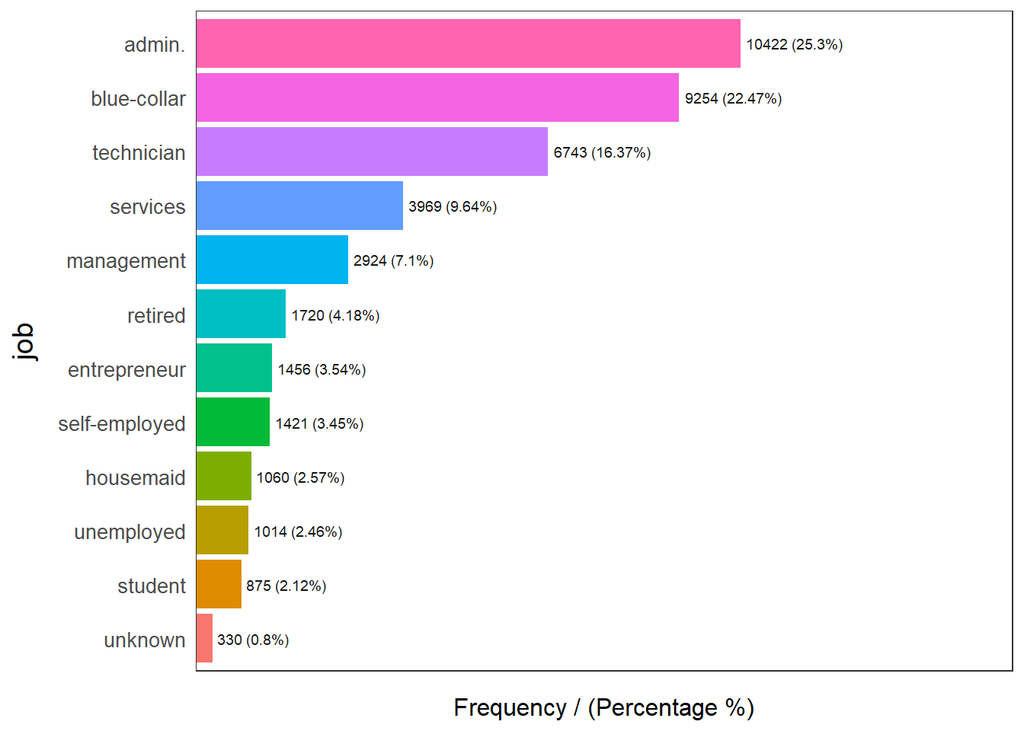

```
##              job frequency percentage cumulative_perc
## 1         admin.     10422      25.30           25.30
## 2    blue-collar      9254      22.47           47.77
## 3     technician      6743      16.37           64.14
## 4       services      3969       9.64           73.78
## 5     management      2924       7.10           80.88
## 6        retired      1720       4.18           85.06
## 7   entrepreneur      1456       3.54           88.60
## 8  self-employed      1421       3.45           92.05
## 9      housemaid      1060       2.57           94.62
## 10    unemployed      1014       2.46           97.08
## 11       student       875       2.12           99.20
## 12       unknown       330       0.80          100.00
```

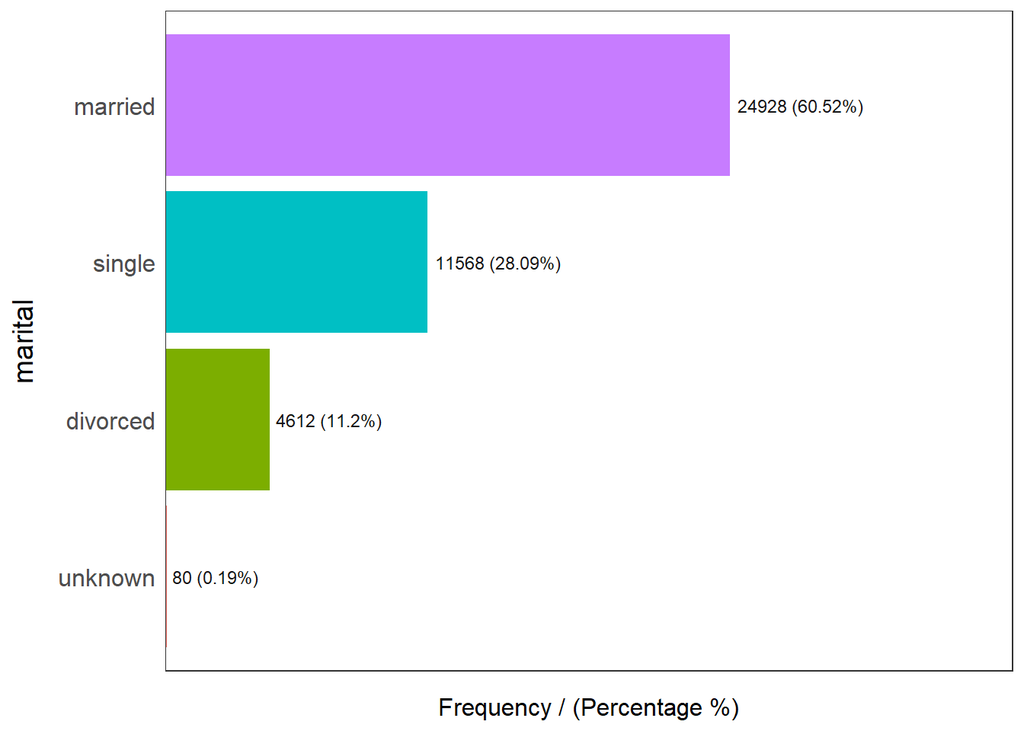

```
##    marital frequency percentage cumulative_perc
## 1  married     24928      60.52           60.52
## 2   single     11568      28.09           88.61
## 3 divorced      4612      11.20           99.81
## 4  unknown        80       0.19          100.00
```

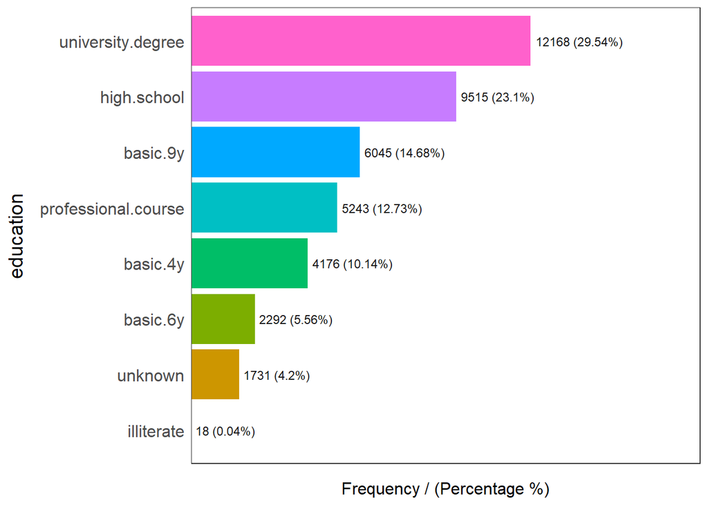

```
##             education frequency percentage cumulative_perc
## 1   university.degree     12168      29.54           29.54
## 2         high.school      9515      23.10           52.64
## 3            basic.9y      6045      14.68           67.32
## 4 professional.course      5243      12.73           80.05
## 5            basic.4y      4176      10.14           90.19
## 6            basic.6y      2292       5.56           95.75
## 7             unknown      1731       4.20           99.95
## 8          illiterate        18       0.04          100.00
```

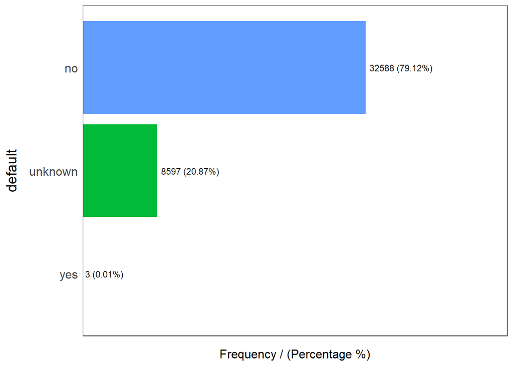

```
##   default frequency percentage cumulative_perc
## 1      no     32588      79.12           79.12
## 2 unknown      8597      20.87           99.99
## 3     yes         3       0.01          100.00
```

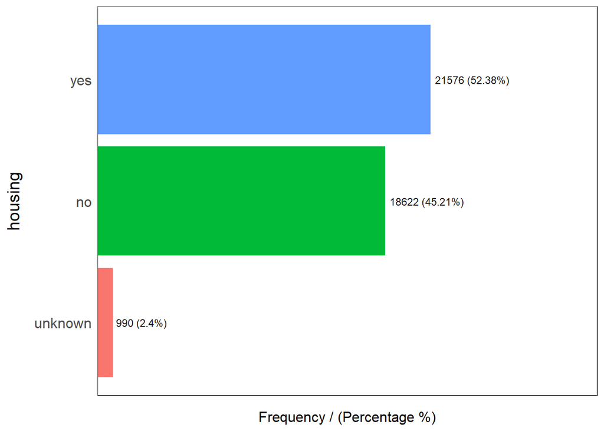

```
##   housing frequency percentage cumulative_perc
## 1     yes     21576      52.38           52.38
## 2      no     18622      45.21           97.59
## 3 unknown       990       2.40          100.00
```

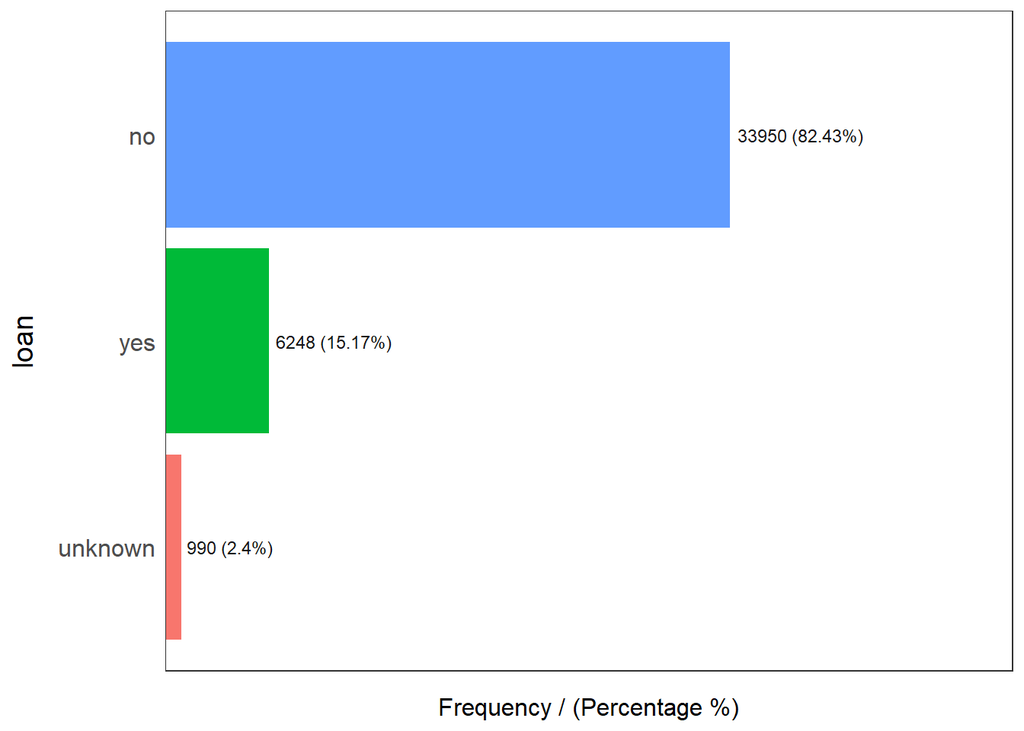

```
##      loan frequency percentage cumulative_perc
## 1      no     33950      82.43           82.43
## 2     yes      6248      15.17           97.60
## 3 unknown       990       2.40          100.00
```

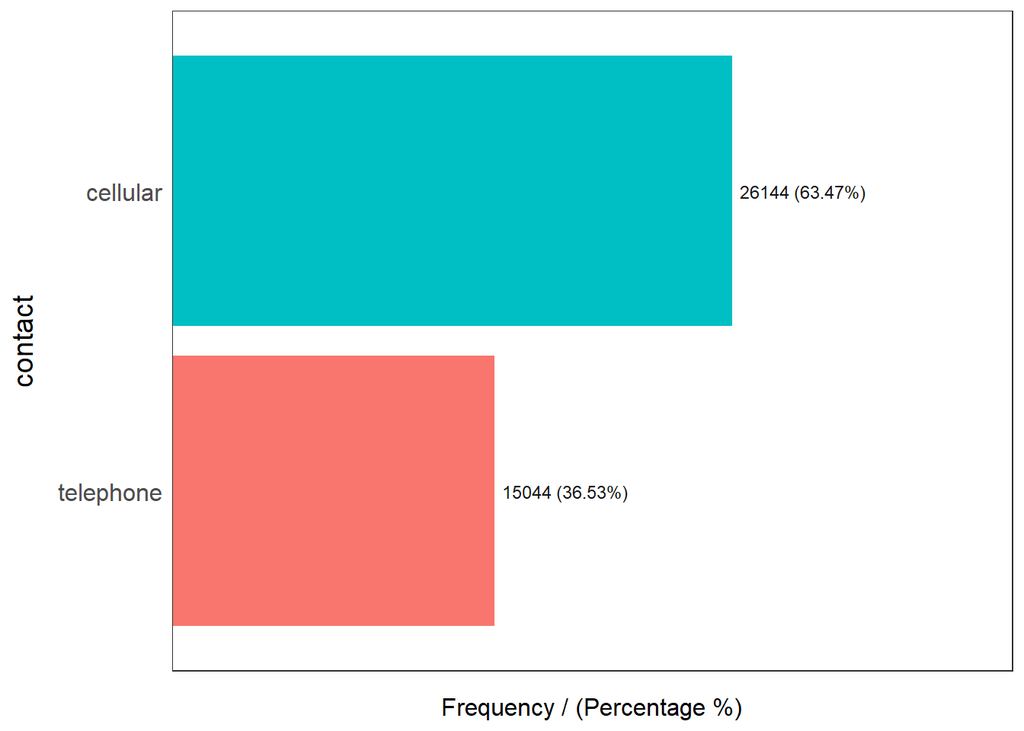

```
##     contact frequency percentage cumulative_perc
## 1  cellular     26144      63.47           63.47
## 2 telephone     15044      36.53          100.00
```

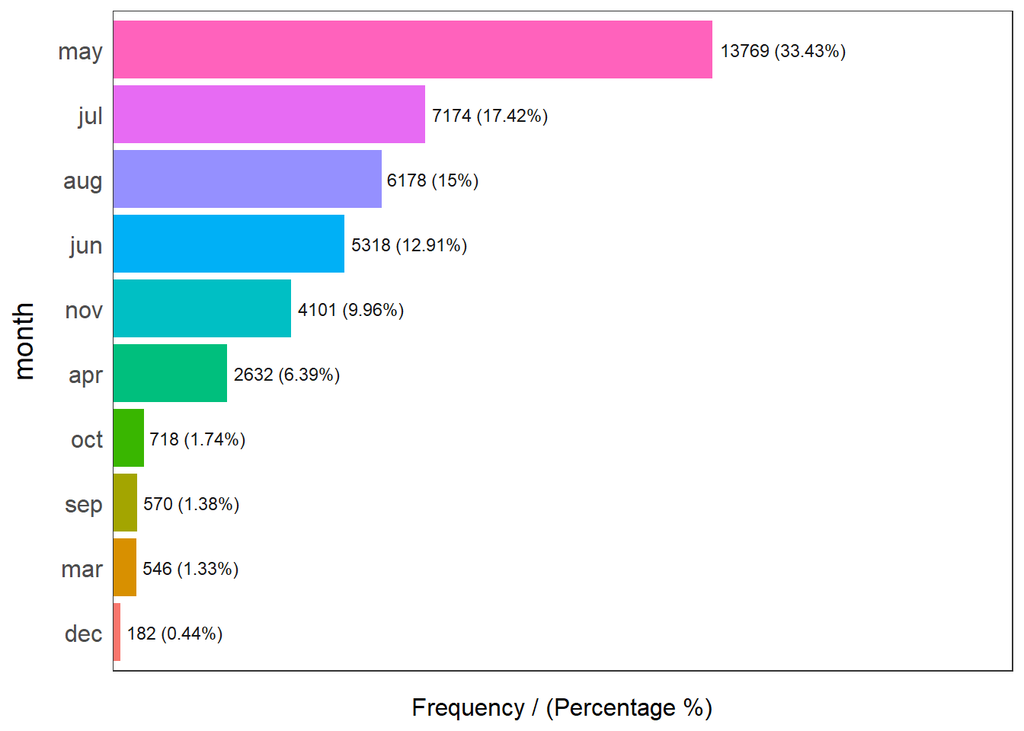

```
##    month frequency percentage cumulative_perc
## 1    may     13769      33.43           33.43
## 2    jul      7174      17.42           50.85
## 3    aug      6178      15.00           65.85
## 4    jun      5318      12.91           78.76
## 5    nov      4101       9.96           88.72
## 6    apr      2632       6.39           95.11
## 7    oct       718       1.74           96.85
## 8    sep       570       1.38           98.23
## 9    mar       546       1.33           99.56
## 10   dec       182       0.44          100.00
```

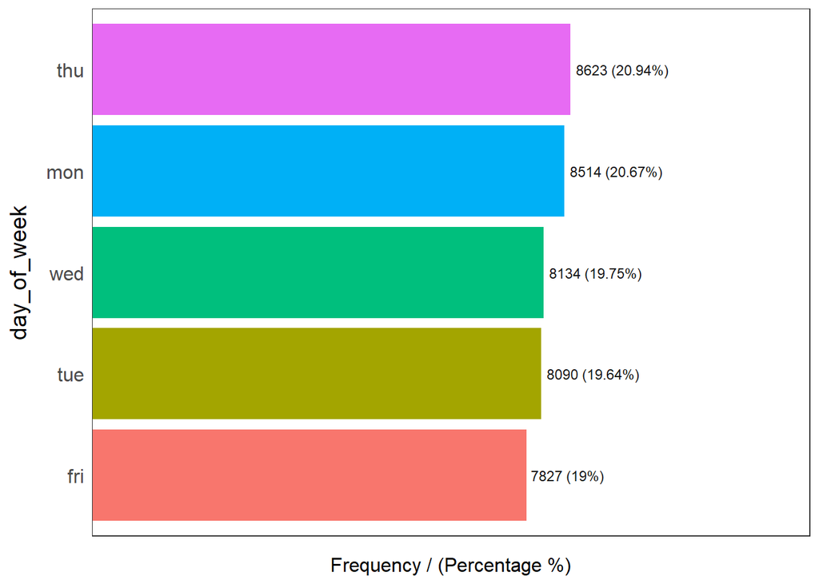

```
##   day_of_week frequency percentage cumulative_perc
## 1         thu      8623      20.94           20.94
## 2         mon      8514      20.67           41.61
## 3         wed      8134      19.75           61.36
## 4         tue      8090      19.64           81.00
## 5         fri      7827      19.00          100.00
```

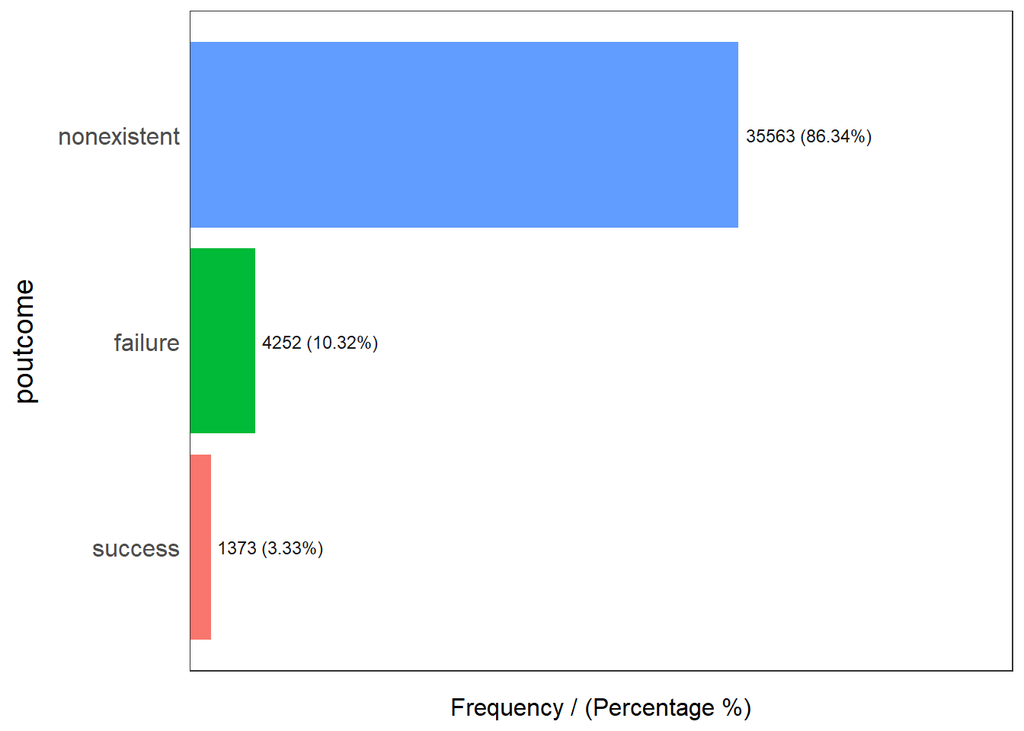

```
##      poutcome frequency percentage cumulative_perc
## 1 nonexistent     35563      86.34           86.34
## 2     failure      4252      10.32           96.66
## 3     success      1373       3.33          100.00
```

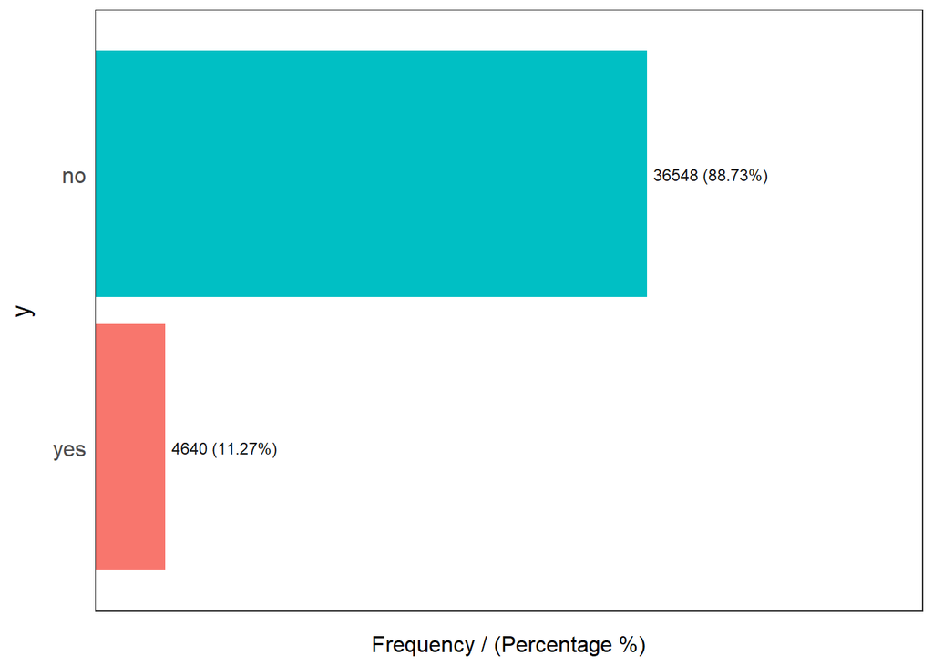

```
##     y frequency percentage cumulative_perc
## 1  no     36548      88.73           88.73
## 2 yes      4640      11.27          100.00
##
##          variable         mean     std_dev variation_coef       p_01     p_05
## 1             age   40.0240604  10.4212500    0.260374632   23.00000   26.000
## 2        duration  258.2850102 259.2792488    1.003849386   11.00000   36.000
## 3        campaign    2.5675925   2.7700135    1.078836903    1.00000    1.000
## 4           pdays  962.4754540 186.9109073    0.194198103    3.00000  999.000
## 5        previous    0.1729630   0.4949011    2.861311858    0.00000    0.000
## 6    emp.var.rate    0.0818855   1.5709597   19.184834048   -3.40000   -2.900
## 7  cons.price.idx   93.5756644   0.5788400    0.006185797   92.20100   92.713
## 8   cons.conf.idx  -40.5026003   4.6281979   -0.114269154  -49.50000  -47.100
## 9       euribor3m    3.6212908   1.7344474    0.478958331    0.65848    0.797
## 10    nr.employed 5167.0359109  72.2515277    0.013983167 4963.60000 5017.500
```

[output cut: 22 more lines]

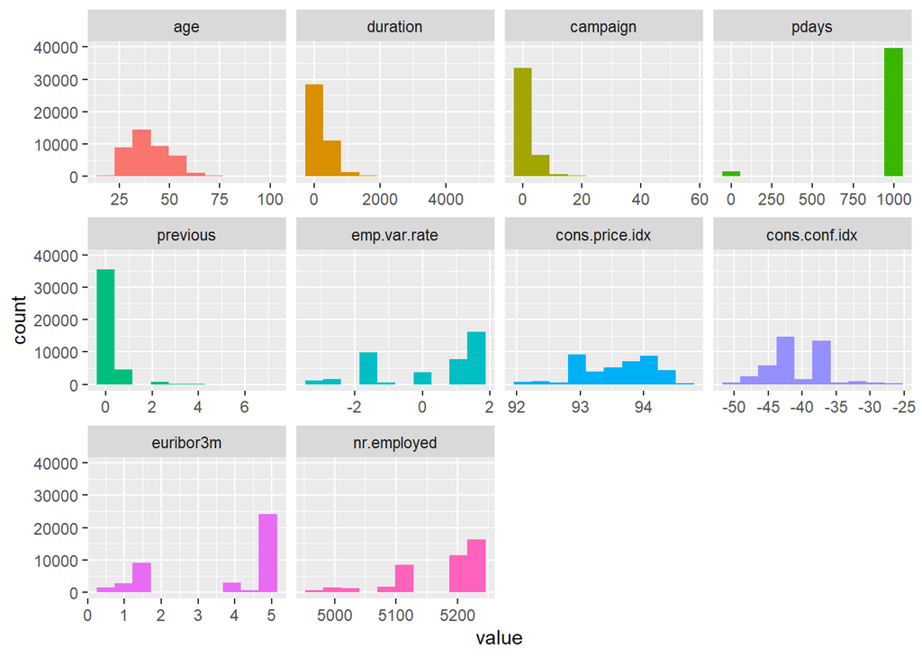

```
## data
##
##  21  Variables      41188  Observations
## --------------------------------------------------------------------------------
## age
##        n  missing distinct     Info     Mean      Gmd      .05      .10
##    41188        0       78    0.999    40.02    11.57       26       28
##      .25      .50      .75      .90      .95
##       32       38       47       55       58
##
## lowest : 17 18 19 20 21, highest: 91 92 94 95 98
## --------------------------------------------------------------------------------
## job
##        n  missing distinct
##    41188        0       12
##
## lowest : admin.       blue-collar  entrepreneur housemaid    management
## highest: services     student      technician   unemployed   unknown
##
## admin. (10422, 0.253), blue-collar (9254, 0.225), entrepreneur (1456, 0.035),
## housemaid (1060, 0.026), management (2924, 0.071), retired (1720, 0.042),
## self-employed (1421, 0.035), services (3969, 0.096), student (875, 0.021),
## technician (6743, 0.164), unemployed (1014, 0.025), unknown (330, 0.008)
## --------------------------------------------------------------------------------
## marital
##        n  missing distinct
##    41188        0        4
##
## Value      divorced  married   single  unknown
## Frequency      4612    24928    11568       80
## Proportion    0.112    0.605    0.281    0.002
## --------------------------------------------------------------------------------
## education
##        n  missing distinct
##    41188        0        8
##
## lowest : basic.4y            basic.6y            basic.9y            high.school         illiterate
## highest: high.school         illiterate          professional.course university.degree   unknown
##
## basic.4y (4176, 0.101), basic.6y (2292, 0.056), basic.9y (6045, 0.147),
```

[output cut: 152 more lines]

```
## Frequency     635    773    650   1071    172   1663   8534     10   7763
## Proportion  0.015  0.019  0.016  0.026  0.004  0.040  0.207  0.000  0.188
##
## Value      5195.8 5228.1
## Frequency    3683  16234
## Proportion  0.089  0.394
## --------------------------------------------------------------------------------
## y
##        n  missing distinct
##    41188        0        2
##
## Value         no   yes
## Frequency  36548  4640
## Proportion 0.887 0.113
## --------------------------------------------------------------------------------
```

```r
# Create a bird's eye view of missing data using naniar library if missing data exists
if(sum(!complete.cases(full_bank)) > 0)
{
  vis_miss(full_bank, cluster = F) + # Without aggregating observations
  labs(title = "NAs in Bank Data from May 2008 - Nov 2010") +
  theme(axis.text.x = element_text(angle=90))
}
```

```r
full_bank[full_bank=="unknown"] <- NA

freq(full_bank, plot = F)
```

```
##              job frequency percentage cumulative_perc
## 1         admin.     10422      25.30           25.30
## 2    blue-collar      9254      22.47           47.77
## 3     technician      6743      16.37           64.14
## 4       services      3969       9.64           73.78
## 5     management      2924       7.10           80.88
## 6        retired      1720       4.18           85.06
## 7   entrepreneur      1456       3.54           88.60
## 8  self-employed      1421       3.45           92.05
## 9      housemaid      1060       2.57           94.62
## 10    unemployed      1014       2.46           97.08
## 11       student       875       2.12           99.20
## 12          <NA>       330       0.80          100.00
##
##    marital frequency percentage cumulative_perc
```

[output cut: 61 more lines]

```
## [1] "Variables processed: job, marital, education, default, housing, loan, contact, month, day_of_week, poutcome, y"
```

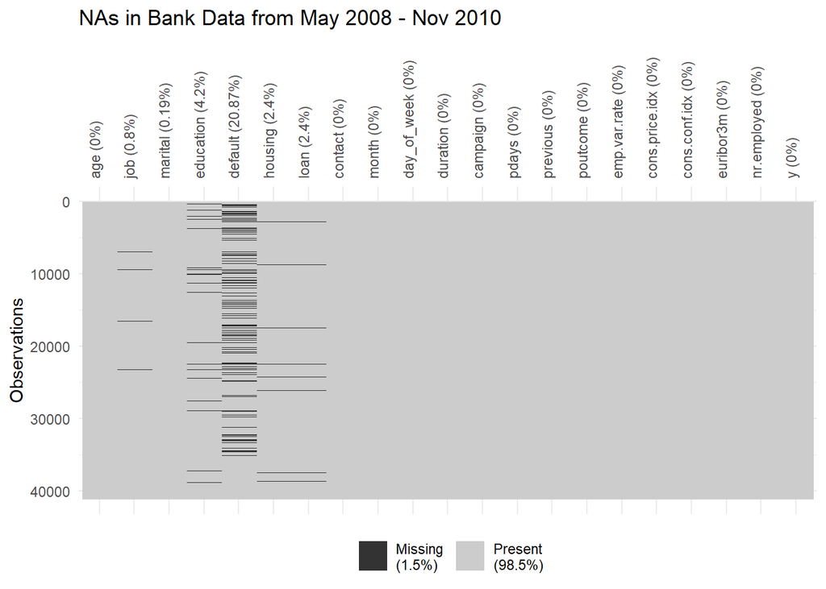

```r
# Create a bird's eye view of missing data using naniar library if missing data exists
vis_miss(full_bank, cluster = F) +
labs(title = "NAs in Bank Data from May 2008 - Nov 2010") +
theme(axis.text.x = element_text(angle=90))
```

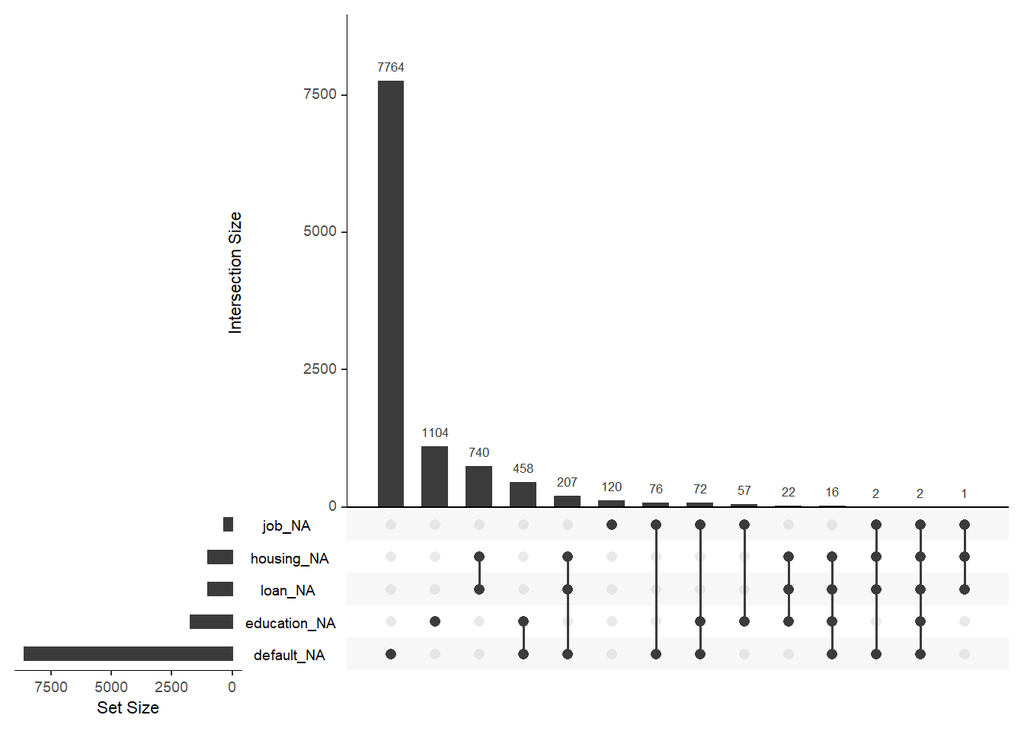

```r
gg_miss_upset(full_bank)
```

Some interesting notes on the missing data is that the majority of the data seems to be the unknown status of whether an individual has defaulted on their credit or not. If default becomes a major predictor for whether a client will subscribe to a bank term deposit or not, some research should be explored here to discover why we cannot accurately define whether an individual defaults on their credit or not.

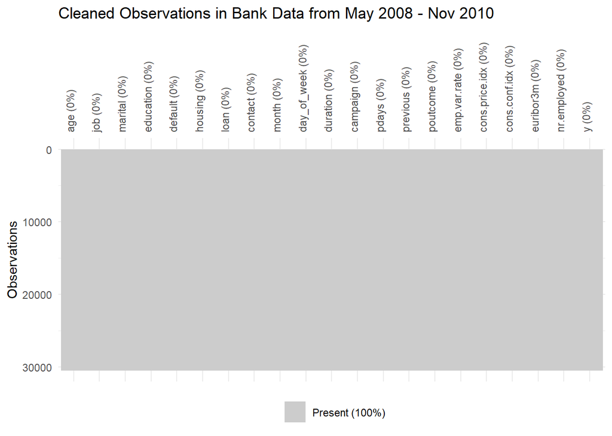

```r
complete_full_bank <- full_bank[complete.cases(full_bank),]

# Transform all chr objects in data frame to a factor class as a secondary data frame object
complete_full_bank <- as.data.frame(unclass(complete_full_bank), stringsAsFactors = T)

vis_miss(complete_full_bank, cluster = F) + # Without aggregating observations b/c takes too long to aggregate
labs(title = "Cleaned Observations in Bank Data from May 2008 - Nov 2010") +
theme(axis.text.x = element_text(angle=90))
```

Now we have no missing data.

## Addressing Character Variable and Numeric Variable

```r
# Checking for number of columns with numeric type
numeric_var_who=sum(sapply(complete_full_bank[,1:21],is.numeric))
numeric_var_who
```

```
## [1] 10
```

```r
# Checking for number of columns with character type
char_var_who=sum(sapply(complete_full_bank[,1:21],is.character))
char_var_who
```

```
## [1] 0
```

```r
# Checking for column names with numeric type
numeric_varname_who=which(sapply(complete_full_bank[,1:21],is.numeric))
numeric_varname_who
```

```
##            age       duration       campaign          pdays       previous
##              1             11             12             13             14
##   emp.var.rate cons.price.idx  cons.conf.idx      euribor3m    nr.employed
##             16             17             18             19             20
```

```r
# Checking for column names with character type
char_varname_who=which(sapply(complete_full_bank[,1:21],is.character))
char_varname_who
```

```
## named integer(0)
```

### Is our Response Variables Unbalanced?

```r
prop.table(table(complete_full_bank$y))
```

```
##
##        no       yes
## 0.8734256 0.1265744
```

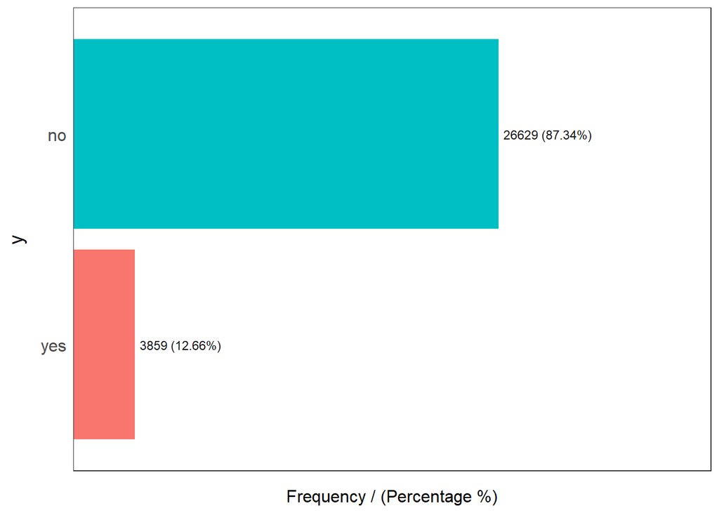

```
##     y frequency percentage cumulative_perc
## 1  no     26629      87.34           87.34
## 2 yes      3859      12.66          100.00
```

```r
freq(complete_full_bank, input="y")
```

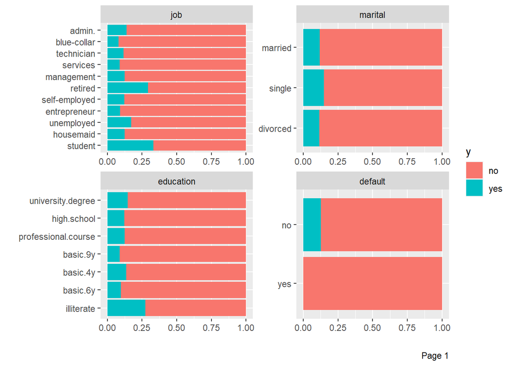

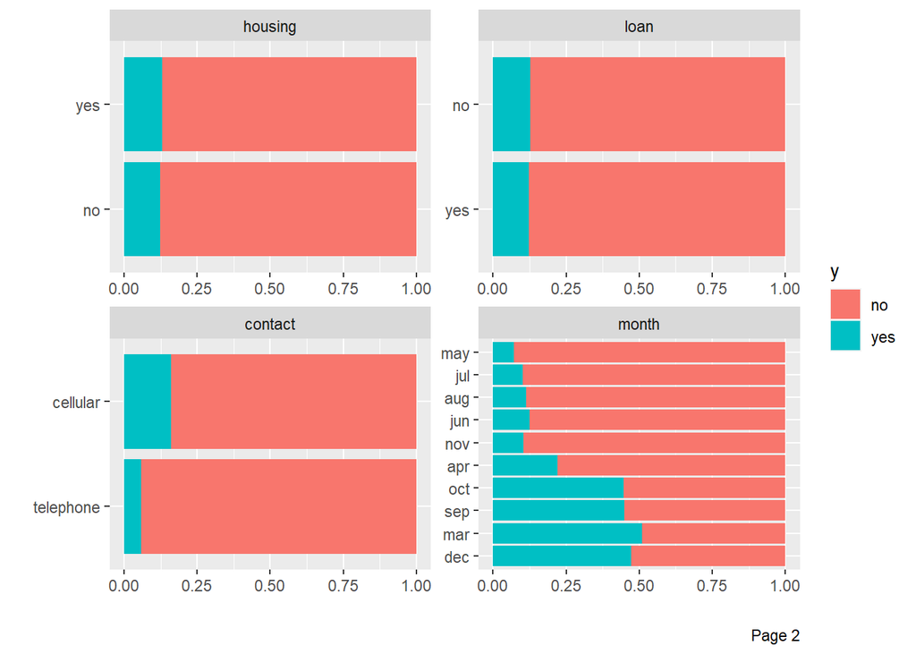

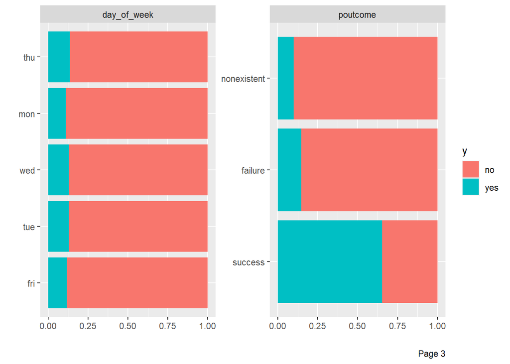

```r
plot_bar(data=complete_full_bank, by = "y", nrow=2, ncol=2)
```

Looking closer at our response variable, we have a significant lower percentage of yes’s versus no’s (12.66% yes’s to 87.34% no’s). With this in mind, we’ll need to ensure either our sampling is weighted, or consider algorithms that can oversample or undersample when fitting our logistic regression model, otherwise we may introduce bias and lower our accuracy on predicting when a client successfully subscribes to a bank term deposit.

### Examining Normality of Numeric Variables

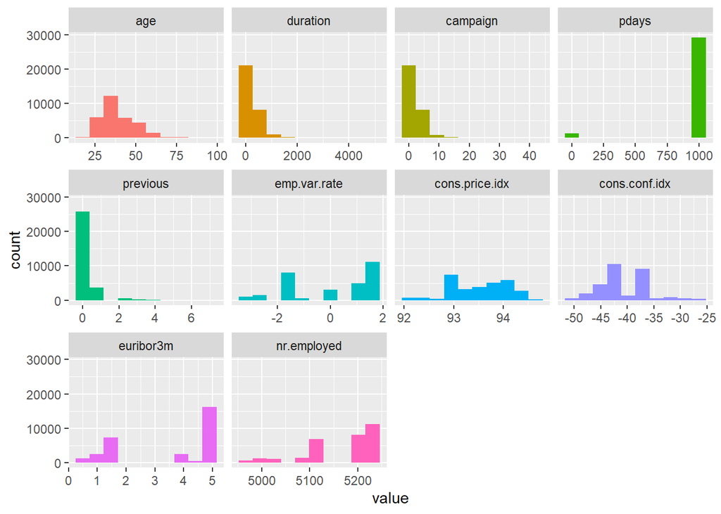

```r
plot_num(complete_full_bank)
```

Looking closer at the histograms of the scale variables, it appears there are some potential normality issues, particularly the pdays.

## Initial Full Logistic Regression Model

Before we go into automatic model variable selection tools, we should attempt to understand the full model and how our explanatory variables may come into play and assess whether the assumptions of logistic regression are met or not.

```r
full.logistic.fit <- glm(y ~ ., data = complete_full_bank, family="binomial")
summary(full.logistic.fit) # Full Model Statistics
```

```
##
## Call:
## glm(formula = y ~ ., family = "binomial", data = complete_full_bank)
##
## Deviance Residuals:
##     Min       1Q   Median       3Q      Max
## -5.8809  -0.3267  -0.1970  -0.1424   3.4386
##
## Coefficients:
##                                Estimate Std. Error z value Pr(>|z|)
## (Intercept)                  -2.740e+02  4.187e+01  -6.544 5.98e-11 ***
## age                          -2.202e-03  2.727e-03  -0.807 0.419423
## jobblue-collar               -2.119e-01  9.079e-02  -2.334 0.019573 *
## jobentrepreneur              -1.705e-01  1.396e-01  -1.222 0.221821
## jobhousemaid                  4.055e-02  1.661e-01   0.244 0.807101
## jobmanagement                -2.075e-02  9.177e-02  -0.226 0.821089
## jobretired                    3.364e-01  1.205e-01   2.791 0.005250 **
## jobself-employed             -7.976e-02  1.253e-01  -0.637 0.524301
## jobservices                  -1.610e-01  9.542e-02  -1.687 0.091559 .
## jobstudent                    2.614e-01  1.244e-01   2.102 0.035565 *
## jobtechnician                 3.660e-02  7.618e-02   0.481 0.630867
## jobunemployed                 3.295e-02  1.383e-01   0.238 0.811663
## maritalmarried               -3.084e-03  7.510e-02  -0.041 0.967246
## maritalsingle                 2.759e-02  8.502e-02   0.324 0.745566
## educationbasic.6y             1.139e-01  1.439e-01   0.792 0.428629
## educationbasic.9y             2.448e-02  1.108e-01   0.221 0.825087
## educationhigh.school          8.818e-02  1.054e-01   0.837 0.402724
## educationilliterate           1.595e+00  8.637e-01   1.847 0.064771 .
## educationprofessional.course  1.349e-01  1.143e-01   1.180 0.237841
## educationuniversity.degree    2.336e-01  1.055e-01   2.213 0.026870 *
## defaultyes                   -7.289e+00  1.135e+02  -0.064 0.948790
## housingyes                   -2.117e-02  4.501e-02  -0.470 0.638095
## loanyes                      -5.676e-02  6.228e-02  -0.911 0.362119
## contacttelephone             -6.670e-01  8.295e-02  -8.042 8.87e-16 ***
## monthaug                      8.510e-01  1.301e-01   6.542 6.06e-11 ***
## monthdec                      2.312e-01  2.271e-01   1.018 0.308752
## monthjul                      4.723e-02  1.064e-01   0.444 0.657161
## monthjun                     -6.701e-01  1.346e-01  -4.977 6.46e-07 ***
## monthmar                      2.089e+00  1.550e-01  13.477  < 2e-16 ***
## monthmay                     -4.357e-01  8.925e-02  -4.882 1.05e-06 ***
```

[output cut: 13 more lines]

```
## emp.var.rate                 -1.899e+00  1.509e-01 -12.580  < 2e-16 ***
## cons.price.idx                2.443e+00  2.739e-01   8.921  < 2e-16 ***
## cons.conf.idx                 2.127e-02  8.427e-03   2.523 0.011622 *
## euribor3m                     2.883e-01  1.463e-01   1.971 0.048711 *
## nr.employed                   8.128e-03  3.447e-03   2.358 0.018361 *
## ---
## Signif. codes:  0 '***' 0.001 '**' 0.01 '*' 0.05 '.' 0.1 ' ' 1
##
## (Dispersion parameter for binomial family taken to be 1)
##
##     Null deviance: 23160  on 30487  degrees of freedom
## Residual deviance: 13902  on 30440  degrees of freedom
## AIC: 13998
##
## Number of Fisher Scoring iterations: 10
```

```r
psuedo_rsq(full.logistic.fit) # Psuedo R Statistic w/ Chi-Sq P-value
```

```
##   psuedo_rsq chisq_pval
## 1  0.3997495          0
```

```r
library(ROCit)
```

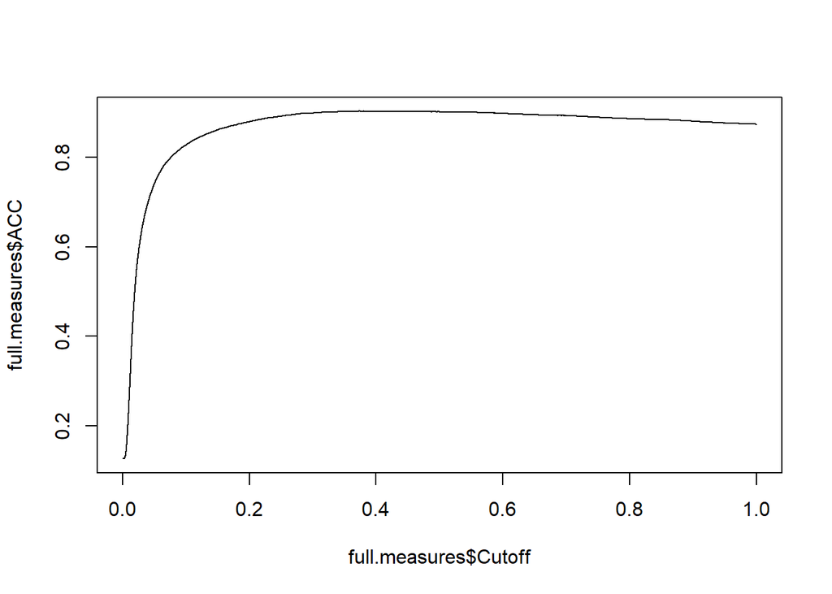

```r
full.measures <- measureit(score = full.logistic.fit$fitted.values, class = full.logistic.fit$y,
                           measure = c("ACC", "SENS", "FSCR"))

plot(full.measures$ACC~full.measures$Cutoff, type = "l")
```

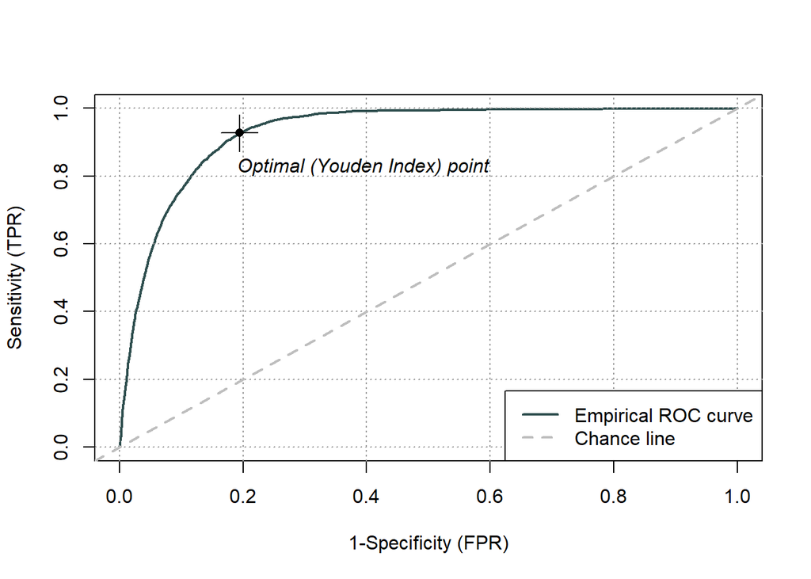

```r
roc_empirical <- rocit(score = full.logistic.fit$fitted.values, class = full.logistic.fit$y, negref = "0")

plot(roc_empirical, values=F)
```

### Interpreting the coefficients The following variables are not useful predictors as they contain moderate to large p-values depending on the confidence level we seek to achieve: * age w/ p-value of 0.42 * Jobs: + entrepreneur – p-value of 0.22 + maid – p-value of 0.81 + management – p-value of 0.82 + employed – p-value of 0.52 + technician – p-value of 0.63 + unemployed – p-value of 0.82 * Martial statuses of married (p-value of .96) and single (p-value of .75) * Education Levels: + basic of 6 years – p-value of .42 + basic of 9 years – p-value of .82 + high school – p-value of .40 + illiterate – p-value of .06 + professional course – p-value of 0.24 * Defaulting on Credit (p-values of .94) * Housing Loan (p-value of .64) * A loan in general (p-value of .36) * Last Month of Contact During Campaign: + July – p-value of .66 + October – p-value of .14 + December – p-value of .31 * Day of the Week of Contact During Campaign: + Monday – p-value of .35 + Thursday – p-value of.08 * The Number of Previous Contacts Performed Before the Campaign – p-value of .41

Additionally, we can observe that for our full model, our residual deviance is 13,902 with an AIC of 13,998. We can also see that our psuedo R^2 value is 0.39975 with an extremely small Chi-squared p-value that it is nonetheless 0.

Lastly, we can see how the full model predicted by the following graphic:

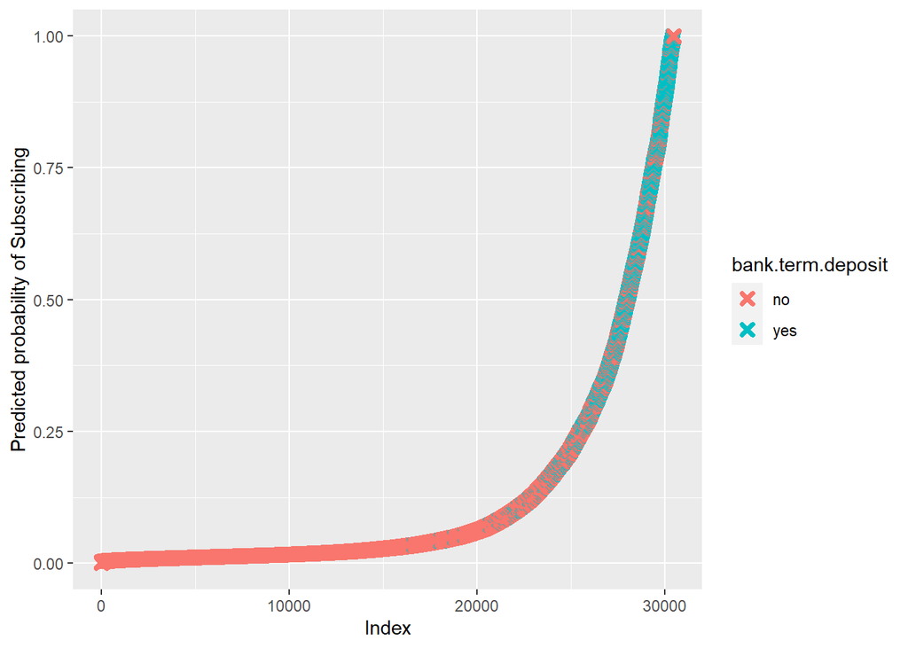

```r
s_plot(full.logistic.fit, complete_full_bank)
```

As you can see, there looks to be some scattered mis-classifications within the yes section. This is perhaps due to unbalanced data that we need to sort out in our refined model with sampling methods as previously mentioned.

## Assumptions Investigation

Now that we understand more about our data and logistic regression model, we should do some preliminary assumptions check for logistic regression. These metrics are important as we will use them to compare our later simpler logistic regression model for performance evaluation.

### Binary/Ordinal Response Variable

```r
nlevels(complete_full_bank$y)
```

```
## [1] 2
```

```r
levels(complete_full_bank$y)
```

```
## [1] "no"  "yes"
```

As you can see above, our response variable, y, consists of two levels, resulting in a binary response. We will move forward with a binary logistic regression model instead of an ordinal logistic regression model.

### Influential Observations

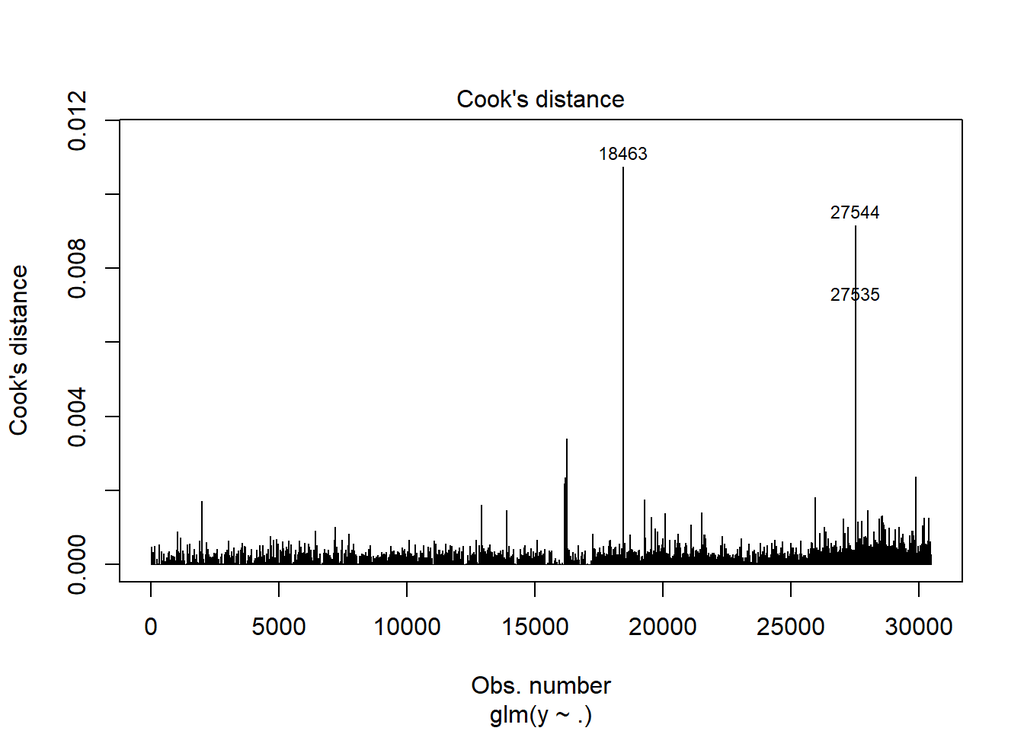

```r
plot(full.logistic.fit, which = 4, id.n = 3)
```

```r
complete_full_bank_2 <- complete_full_bank[-c(18463,27544,27535)]
```

### Linearity of Continuous/Scale Variables vs. Log Odds of Response Variable

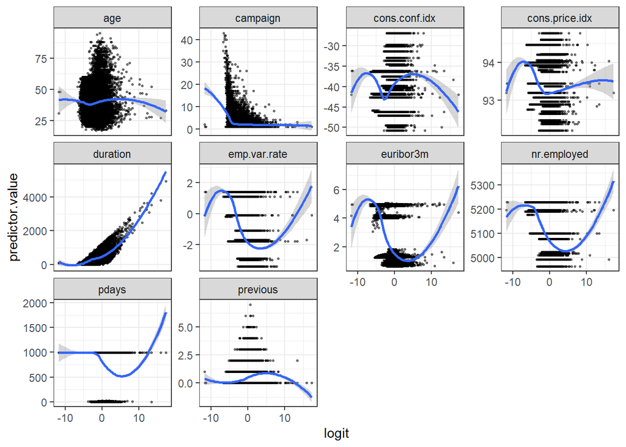

```r
numeric_pred <- complete_full_bank %>% select_if(is.numeric)
numeric_pred_names <- colnames(numeric_pred)

# binding logit and numeric predictors for scatterplots
linearity_data <- numeric_pred %>%
  mutate(logit = log(full.logistic.fit$fitted.values/(1-full.logistic.fit$fitted.values))) %>%
  gather(key = "predictors", value = "predictor.value", -logit)

ggplot(linearity_data, aes(logit, predictor.value))+
  geom_point(size = 0.5, alpha = 0.5) +
  geom_smooth(method = "loess", formula = "y~x") +
  theme_bw() +
  facet_wrap(~predictors, scales = "free_y")
```

For all other variables, transformations may be beneficial for classifying, but for now we will leave them as is.

### Multicollinearity of Explanatory Variables

The below correlation table shows the correlation between the numerical variables: * nr.employed and emp.var.rate are 91% correlated. * nr.employed and euribor3m are 95% correlated. * emp.var.rate and euribor3m are 97% correlated. * cons.price.idx and emp.var.rate are 78% correlated. * cons.price.idx and euribor3m are 69% correlated. * cons.price.idx and nr.employed are 52% correlated.

Furthermore, we do have a moderate multicollinearity issue with some variables for previous and pdays. We may want to examine them closer.

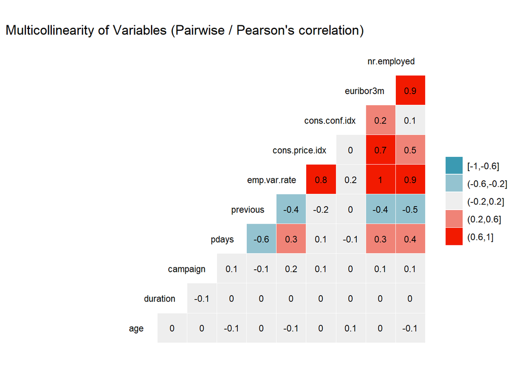

```r
ggcorr(data=numeric_pred, label = T, nbreaks=5, label_size = 3, hjust = 0.9, size = 3, layout.exp = 4) +
  labs(title = "Multicollinearity of Variables (Pairwise / Pearson's correlation)")
```

For variables with moderate to large Pearson’s correlation, we’ll need to examine the VIF to see which variables may be need to be removed due to a problematic amount of collinearity.

```r
vif(full.logistic.fit)
```

```
##                      GVIF Df GVIF^(1/(2*Df))
## age              2.340059  1        1.529725
## job              5.726224 10        1.091173
## marital          1.435575  2        1.094603
## education        3.115863  6        1.099339
## default          1.000001  1        1.000000
## housing          1.012288  1        1.006125
## loan             1.005482  1        1.002737
## contact          2.072223  1        1.439522
## month           60.240325  9        1.255691
## day_of_week      1.068600  4        1.008328
## duration         1.233461  1        1.110613
## campaign         1.053517  1        1.026410
## pdays           11.181093  1        3.343814
## previous         4.396976  1        2.096897
## poutcome        24.437475  2        2.223382
## emp.var.rate   125.803500  1       11.216216
## cons.price.idx  65.977749  1        8.122669
## cons.conf.idx    5.454985  1        2.335591
## euribor3m      132.895778  1       11.528043
## nr.employed    168.472250  1       12.979686
```

As a rule of thumb, we should pay attention to variables with a VIF higher than 5 or 10, but we’ll use 5 for logistic regression. The following variables are showing significant VIF values: * job * month * pdays * poutcome * emp.var.rate * cons.price.idx * cons.conf.idx * euribor3m * nr.employed

## PCA Examination

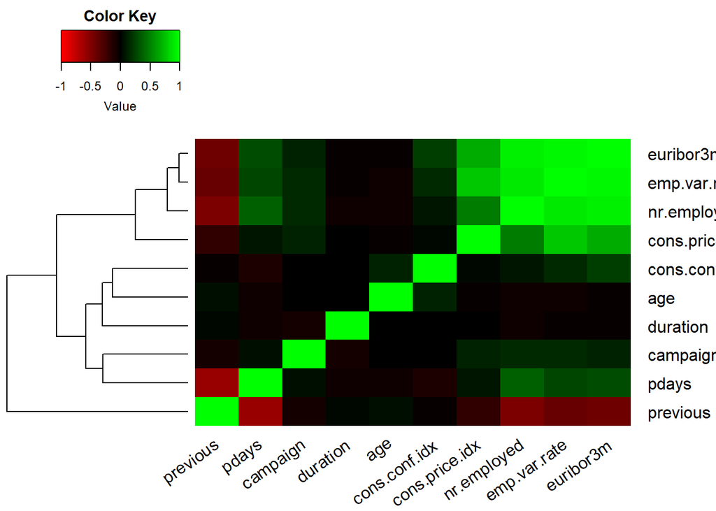

```r
numeric_preds_bank <- complete_full_bank %>% keep(is.numeric)
my.cor <- cor(numeric_preds_bank)
library(gplots)
library(ggplot2)
heatmap.2(my.cor,
          col=redgreen(75),
          density.info="none",
          trace="none",
          dendrogram=c("row"),
          symm=F,
          symkey=T,
          symbreaks=T,
          scale="none",
          srtCol = 35)
```

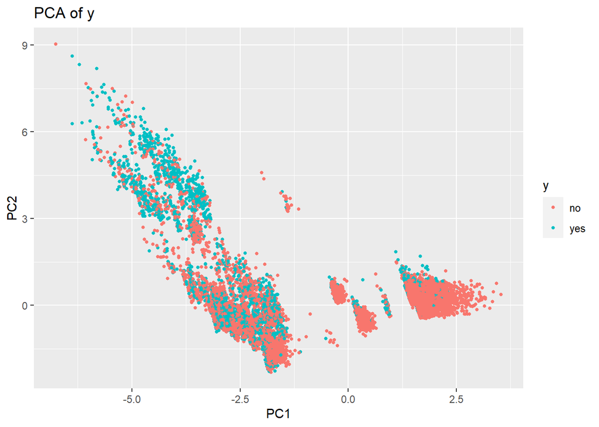

```r
#Another option here would be to do PCA among the continous predictors to see
#if they seperate out.  Or a heatmap.
pc.result<-prcomp(numeric_preds_bank %>% keep(is.numeric),scale.=TRUE)
pc.scores<-pc.result$x
pc.scores<-data.frame(pc.scores)
pc.scores$y<-complete_full_bank$y
#Use ggplot2 to plot the first few pc's
ggplot(data = pc.scores, aes(x = PC1, y = PC2)) +
  geom_point(aes(col=y), size=1)+
  ggtitle("PCA of y")
```

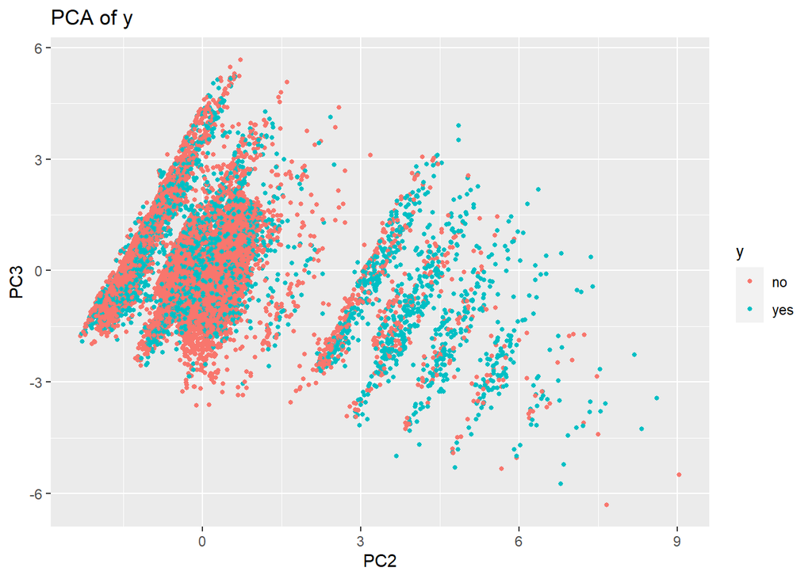

```r
ggplot(data = pc.scores, aes(x = PC2, y = PC3)) +
  geom_point(aes(col=y), size=1)+
  ggtitle("PCA of y")
```

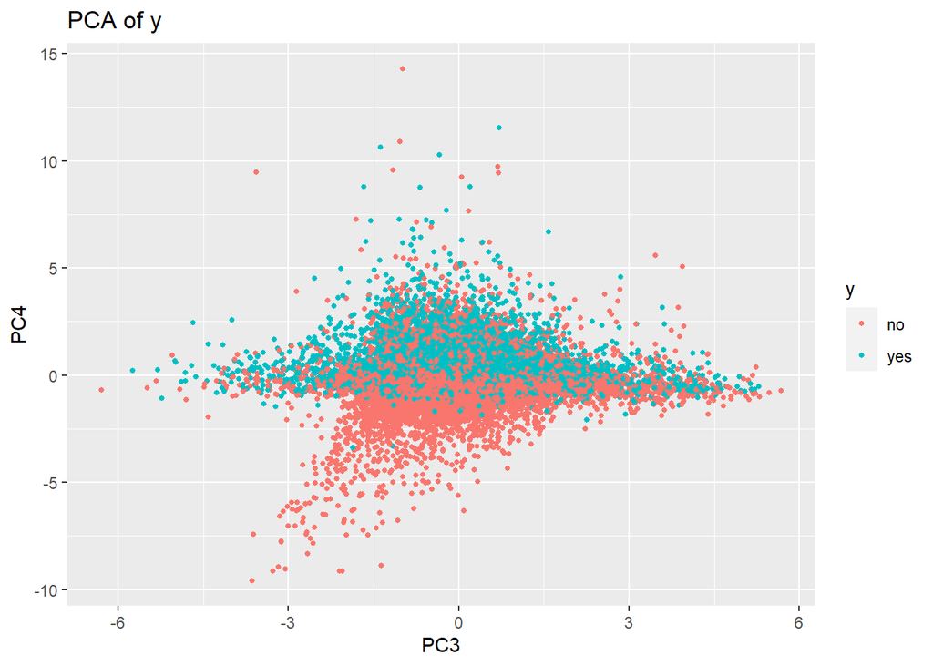

```r
ggplot(data = pc.scores, aes(x = PC3, y = PC4)) +
  geom_point(aes(col=y), size=1)+
  ggtitle("PCA of y")
```

There does not seem to be a large separation with PCA.

## Second Logistic Regression Model

```r
logistic.fit.2 <- glm(y ~ . -nr.employed -euribor3m -cons.conf.idx -cons.price.idx -emp.var.rate -poutcome -pdays -month -job, data = complete_full_bank, family="binomial")

summary(logistic.fit.2)
```

```
##
## Call:
## glm(formula = y ~ . - nr.employed - euribor3m - cons.conf.idx -
##     cons.price.idx - emp.var.rate - poutcome - pdays - month -
##     job, family = "binomial", data = complete_full_bank)
##
## Deviance Residuals:
##     Min       1Q   Median       3Q      Max
## -5.4573  -0.4521  -0.3237  -0.2100   3.0404
##
## Coefficients:
##                                Estimate Std. Error z value Pr(>|z|)
## (Intercept)                  -4.031e+00  1.585e-01 -25.435  < 2e-16 ***
## age                           1.930e-02  2.045e-03   9.437  < 2e-16 ***
## maritalmarried                9.267e-02  6.681e-02   1.387 0.165409
## maritalsingle                 4.750e-01  7.437e-02   6.388 1.68e-10 ***
## educationbasic.6y            -2.541e-01  1.272e-01  -1.997 0.045795 *
## educationbasic.9y            -3.506e-01  9.502e-02  -3.689 0.000225 ***
## educationhigh.school         -4.543e-02  8.387e-02  -0.542 0.588020
## educationilliterate           1.172e+00  7.556e-01   1.550 0.121048
## educationprofessional.course  5.500e-02  8.962e-02   0.614 0.539405
## educationuniversity.degree    2.083e-01  7.961e-02   2.617 0.008869 **
## defaultyes                   -9.139e+00  1.128e+02  -0.081 0.935448
## housingyes                    3.387e-03  4.003e-02   0.085 0.932580
## loanyes                      -8.820e-02  5.573e-02  -1.583 0.113478
## contacttelephone             -9.533e-01  5.417e-02 -17.599  < 2e-16 ***
## day_of_weekmon               -3.426e-02  6.568e-02  -0.522 0.601914
## day_of_weekthu                7.956e-02  6.341e-02   1.255 0.209550
## day_of_weektue                1.339e-01  6.454e-02   2.074 0.038055 *
## day_of_weekwed                9.480e-02  6.447e-02   1.470 0.141466
## duration                      3.832e-03  7.159e-05  53.531  < 2e-16 ***
## campaign                     -1.081e-01  1.231e-02  -8.779  < 2e-16 ***
## previous                      8.452e-01  2.915e-02  28.992  < 2e-16 ***
## ---
## Signif. codes:  0 '***' 0.001 '**' 0.01 '*' 0.05 '.' 0.1 ' ' 1
##
## (Dispersion parameter for binomial family taken to be 1)
##
##     Null deviance: 23160  on 30487  degrees of freedom
## Residual deviance: 17562  on 30467  degrees of freedom
## AIC: 17604
##
## Number of Fisher Scoring iterations: 10
```

```r
psuedo_rsq(logistic.fit.2)
```

```
##   psuedo_rsq chisq_pval
## 1  0.2417266          0
```

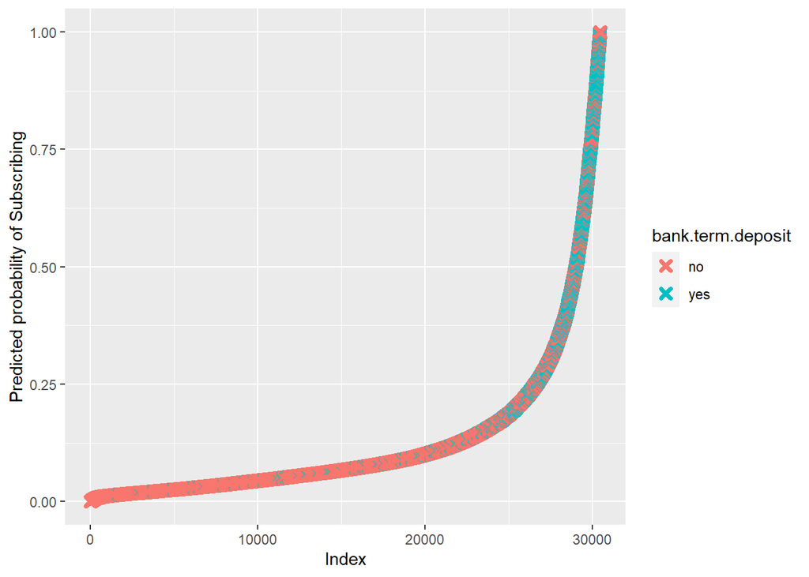

```r
s_plot(logistic.fit.2, complete_full_bank_2)
```

After adjusting the model for multicollinearity problems, we can now see that our model has worsened in performance. However, it does seem that our s-plot is starting to form when compared with the initial full model.

## Model Selection

As we can see, manually modifying and tweaking a model can have adverse results. With this we’ll introduced a third and final model to do a comparison with using automatic variable selection method, LASSO, for this, we’ll need to create a sampling of test data to train the model and then a test set to predict with. We’ll use a 80:20 split and balance our data.

```r
set.seed(2008)

training_samples <- complete_full_bank_2$y %>% createDataPartition(p=0.8, list = F)

train.data <- complete_full_bank[training_samples,]
test.data <- complete_full_bank[-training_samples,]

# Create matrix of predictors & convert to categorical predictors to appropriate dummy values
## Dummy code categorical predictor variables
x <- model.matrix(y~., train.data)[,-1]
## Convert outcome/class to numerical variable
y <- ifelse(train.data$y == "no", 1, 0)

# Source on stepping through Penalized Logistic Regression: http://www.sthda.com/english/articles/36-classification-methods-essentials/149-penalized-logistic-regression-essentials-in-r-ridge-lasso-and-elastic-net/#compute-lasso-regression
```